# Low dimensional visualizations

### 1.3.3 Plots for two continuous variables

#### 1.3.3.1 Scatter plots

Scatter plots are a useful plot type for easily visualizing the relationship between two continuous variables. Here, dots are used to represent pairs of values corresponding to the two considered variables. The position of each dot on the horizontal (`x`) and vertical (`y`) axis indicates values for an individual data point.

In the next example, we analyze the relationship between the engine displacement in liters `displ` and the highway miles per gallon `hwy` from the `mpg` dataset:

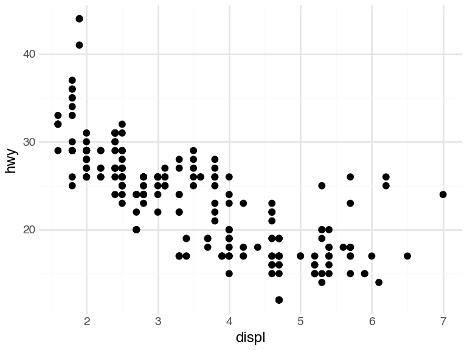

```python
(ggplot(mpg_df, aes('displ', 'hwy')) + geom_point() + mytheme)
```

We can modify the previous plot by coloring the points depending on the vehicle class:

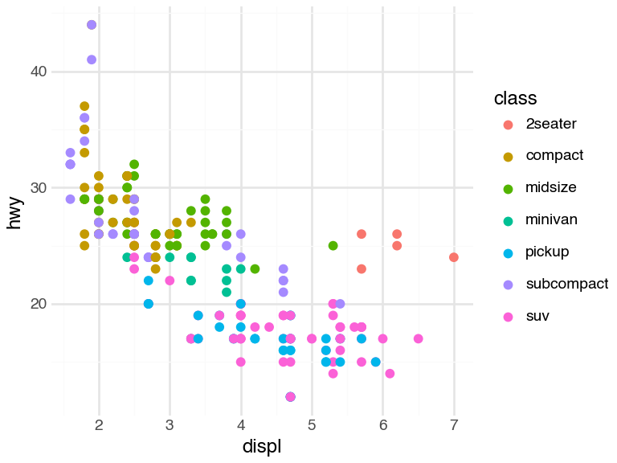

```python
(ggplot(mpg_df, aes('displ', 'hwy', color='class')) + geom_point() + mytheme)
```

Sometimes, too many colors can be hard to distinguish. In such cases, we can use `facet` to separate them into different plots:

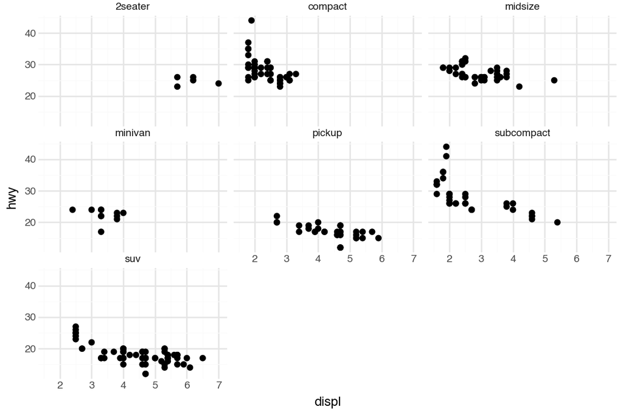

```python
(ggplot(mpg_df, aes('displ', 'hwy')) + geom_point() + facet_wrap('~class')
   + mytheme + theme(figure_size=(6,4)))
```

##### 1.3.3.1.1 Text labeling

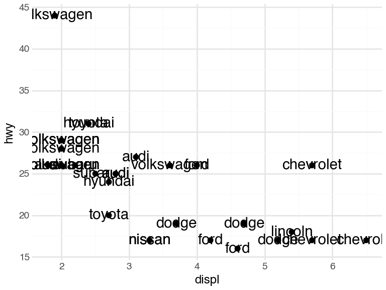

```python
mpg_subset = mpg_df.sample(n=30, random_state=12)
(ggplot(mpg_subset, aes('displ', 'hwy', label='manufacturer')) + geom_point() + geom_text() + mytheme)
```

##### 1.3.3.1.2 Log scaling

We consider another example where we want to plot the weights of the brain and body of different animals using the dataset `Animals`. This is what we obtain after creating a scatterplot.

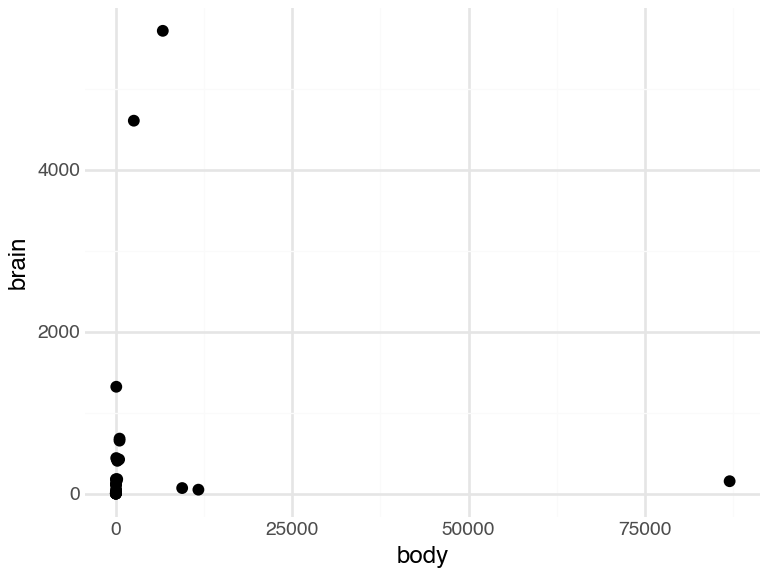

```python
animals_df = pd.read_csv("https://raw.github.com/vincentarelbundock/Rdatasets/master/csv/MASS/Animals.csv")
(ggplot(animals_df, aes('body', 'brain')) + geom_point() + mytheme)
```

We can clearly see that there are a few points which are notably larger than most of the points. This makes it harder to interpret the relationships between most of these points. In such cases, we can consider **logarithmic** transformations and/or scaling. More precisely, a first idea would be to manually transform the values into a logarithmic space and plot the transformed values instead of the original values:

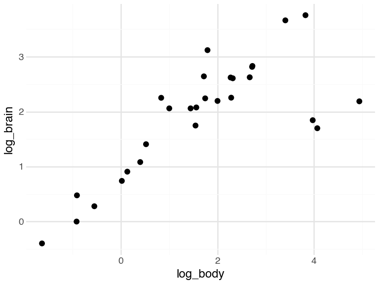

```python
animals_df["log_body"] = np.log10(animals_df["body"])
animals_df["log_brain"] = np.log10(animals_df["brain"])
(ggplot(animals_df, aes('log_body', 'log_brain')) + geom_point() + mytheme)
```

Alternatively, `plotnine` offers to simply scale the data without the need to transform. This can be done with the help of the functions `scale_x_log10()` and `scale_y_log10()` which allow appropriate scaling and labeling of the axes:

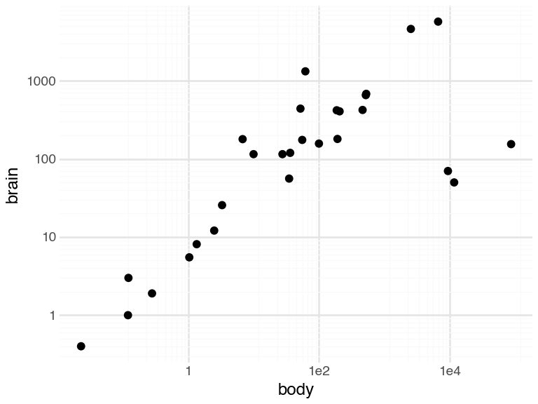

```python
(ggplot(animals_df, aes('body', 'brain')) + geom_point() + scale_x_log10() + scale_y_log10() + mytheme)
```

## 1.4 2D-Density plots

Using scatterplots can become problematic when dealing with a huge number of points. This is due to the fact that points may overlap and we cannot clearly see how many points are at a certain position. In such cases, a 2D density plot is particularly well suited. This plot counts the number of observations within a particular area of the 2D space.

The function `geom_bin_2d()` is creates 2D density plots in python:

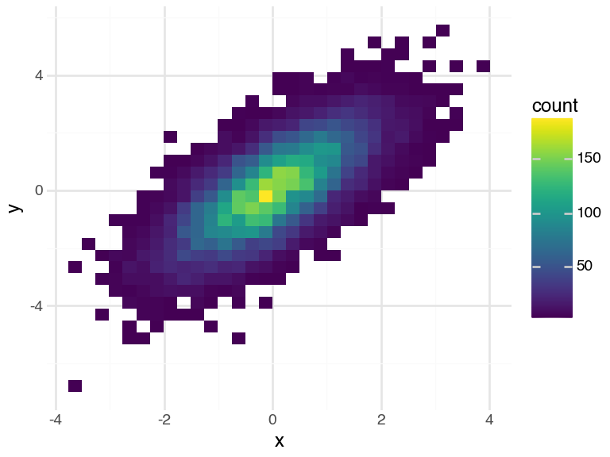

```python
x = np.random.randn(10000)
y = x + np.random.randn(10000)
df = pd.DataFrame({'x': x, 'y': y})
(ggplot(df, aes('x', 'y')) + geom_bin_2d() + mytheme)
```

#### 1.4.0.1 Line plots

A line plot can be considered for connecting a series of individual data points or to display the trend of a series of data points. This can be particularly useful to show the shape of data as it flows and changes from point to point. We can also show the strength of the movement of values up and down through time.

As an example we show the connection between the individual datapoints of unemployment rate over the years:

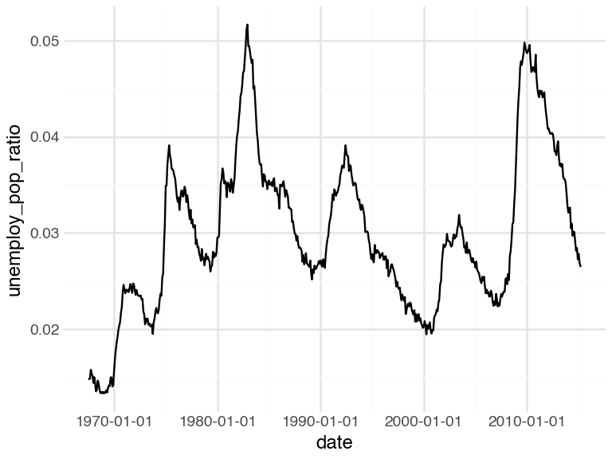

```python
(ggplot(economics, aes(x='date', y='unemploy_pop_ratio'))
  + geom_line()
  + mytheme)
```

## 1.5 Further plots for low dimensional data

### 1.5.1 Plot matrix

A plot matrix is useful for exploring the distributions and correlations of a few variables in a matrix-like representation. Here, for each pair of considered variables, a scatterplot is shown. Moreover, a density plot is created for every single variable (diagonal).

We can use the function `sns.pairplot()` from the library `seaborn` for constructing plot matrices:

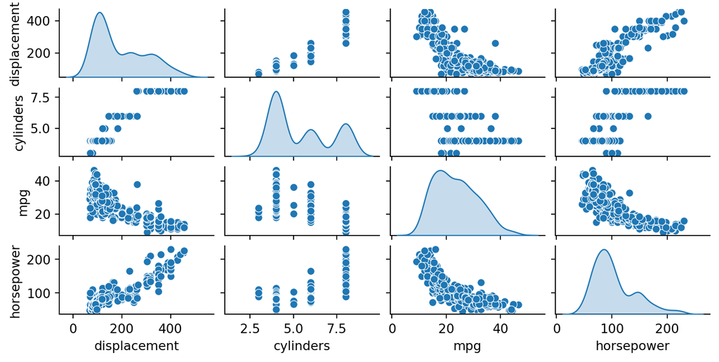

```python
import seaborn as sns
mpg = sns.load_dataset('mpg')
columns_to_plot = ['displacement', 'cylinders', 'mpg', 'horsepower']
sns.pairplot(mpg, vars=columns_to_plot, kind='scatter', diag_kind='kde', aspect=2, size=1)
```

This plot is recommended and suited for a handful of variables but does not scale up to much more variables.

## 1.6 Summary

This chapter covered the basics of the grammar of graphics and `plotnine` to plot low dimensional data. We introduced the different types of plots such as histograms, boxplots or barplots and discussed when to use which plot.

## 1.7 Resources

- The ggplot book: https://ggplot2-book.org/
- The plotnine guide: https://plotnine.org/reference/
- Udacity’s Data Visualization and D3.js
  - https://www.udacity.com/courses/all
- Graphics principles
  - https://onlinelibrary.wiley.com/doi/full/10.1002/pst.1912
  - https://graphicsprinciples.github.io/

## Footnotes

[^1]: https://en.wikipedia.org/wiki/Scientific_method
[^2]: There does not seem to be any widely accepted heuristics to choose the number of bins of a histogram based on data. We recommend trying different values if the default seems to be suboptimal.